# TousAntiCovid

FD

2020-12-23

# Data

- TousAntiCovid: [open data, official source](https://www.data.gouv.fr/fr/datasets/metriques-dutilisation-de-lapplication-tousanticovid/)
- Epidemic data: [JHU data](https://github.com/CSSEGISandData/COVID-19/tree/master/csse_covid_19_data/csse_covid_19_time_series), because recorded as function of date of the result’s announcement.

```r
# Load and format data

# 1) TAC
# Data Source : https://www.data.gouv.fr/fr/datasets/metriques-dutilisation-de-lapplication-tousanticovid/
# URL of the data on data.gouv.fr
URL <- "https://www.data.gouv.fr/fr/datasets/r/0e2168ec-24c7-4b49-a900-c7dd12f8e88c"

# Download and read data
today <- Sys.Date() # today's date
dataFile <- paste0("data/TAC_", today, ".csv") # name file with today's date
download.file(URL, dataFile) # download file from repo
dat <- read.csv(dataFile)

## Description from the website (2020-12-23)
## Le présent jeu de données informe pour chaque jour depuis le lancement de l'application le 2 juin 2020 :
##
## Total cumulé du nombre d'applications enregistrées moins le nombre de désenregistrements.
## Total cumulé d’utilisateurs notifiés par l’application : le nombre d’utilisateurs notifiés par l’application comme contacts à risque suite à une exposition à la COVID-19, depuis le 2 juin 2020.
## Total cumulé d’utilisateurs se déclarant comme des cas de COVID-19 par jour : le nombre d’utilisateurs qui se sont déclarés comme des cas de COVID-19 dans l’application, depuis le 2 juin 2020.

# Check data
# Time differences between dates
unique(diff(as.Date(dat$date))) # -> there are some gaps in the data

# New columns with delta between dates
dat$diffDate <- c(NA, diff(as.Date(dat$date))) # Difference in days between data points
# for the other columns, divide by the time difference to have differences per day
# (otherwise data not comparable when different time differences)
dat$diffRegisterPerDay <- c(NA, diff(dat$register) / dat$diffDate[-1])
dat$diffQRPerDay <- c(NA, diff(dat$qrCode) / dat$diffDate[-1])
dat$diffNotifPerDay <- c(NA, diff(dat$notified) / dat$diffDate[-1])

# Create new dataset without gaps in the dates
# New dates, without gaps
rangeDates <- range(as.Date(dat$date))
allDates <- seq(rangeDates[1], rangeDates[2], by="days")
dat.temp <- as.data.frame(as.character(allDates))
names(dat.temp) <- "date"

# Merge the datasets by date
tmp <- merge(dat, dat.temp, by = "date", all = TRUE)
# note: this adds NA at the dates where there were no data;
# these dates are put at the end of the table

# Sort the new dataset by date
sortedDateIndex <- sort(as.character(tmp$date), index.return = TRUE)$ix
dat.all <- tmp[sortedDateIndex, ]

# Add day of the week
dat.all$weekDay <- weekdays(as.Date(dat.all$date))

# Load function to compute sliding average
source("commonFuncs.R")

# Remove negative values
dat.all$diffNotifPerDay[dat.all$diffNotifPerDay < 0 ] <- NA

# Compute the average values, 1-week window, focal point in the middle
dat.all$diffRegisterPerDay.WeekAve <- sliding.ave(dat.all$diffRegisterPerDay)
dat.all$diffQRPerDay.WeekAve <- sliding.ave(dat.all$diffQRPerDay)
dat.all$diffNotifPerDay.WeekAve <- sliding.ave(dat.all$diffNotifPerDay)
dat.all$register.WeekAve <- sliding.ave(dat.all$register)
dat.all$date <- as.Date(dat.all$date)
```

```r
# 2) Data from JHU
# The date in these data is the date of the result's annoucement
URL <- "https://raw.githubusercontent.com/CSSEGISandData/COVID-19/master/csse_covid_19_data/csse_covid_19_time_series/time_series_covid19_confirmed_global.csv"
# Download and read data
dataFile <- paste0("data/JHU_cases_all_", today, ".csv") # name file with today's date
download.file(URL, dataFile) # download file from repo
datJHU <- read.csv(dataFile, header = TRUE, check.names = FALSE)
# Extract data about France
datJHU.France <- datJHU[datJHU$`Country/Region` == "France", ]

# Collapse data for all France (including DOM TOM)
datJHU.France.agg <- apply(datJHU.France[, -(1:4)], 2, sum)
# Need to reformat the data: have one column for dates and one column for values
datJHUFr <- data.frame(matrix(0, ncol = 2, nrow = length(datJHU.France.agg)))
datJHUFr$date <- as.Date(names(datJHU.France.agg), format = "%m/%d/%y")
datJHUFr$cumP <- unname(datJHU.France.agg)
datJHUFr <- datJHUFr[, -(1:2)]
# Get week day
datJHUFr$weekDay <- weekdays(as.Date(datJHUFr$date))
# Extract data per day (JHU provides cumulative values)
datJHUFr$P <- c(datJHUFr[1, "cumP"], diff(datJHUFr$cumP))
# Add the sliding window value to the JHU data
datJHUFr$P.WeekAve <- sliding.ave(datJHUFr$P, winwdt = 7, pos = 4, na.rm = TRUE)
```

```r
# Merge the datasets
dat.withEpi <- merge(dat.all, datJHUFr, by = "date")
names(dat.withEpi)[9] <- "weekDay"
```

# Plots

```r
# Load plot settings
source("commonPlot.R")
```

## TAC, registrations

### Number of registered users, over time

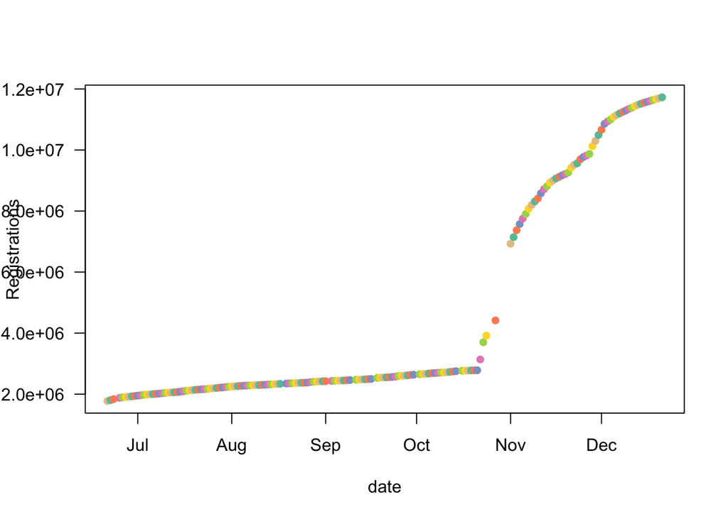

```r
plot(as.Date(dat.all$date), dat.all$register,
     xlab = "date",
     ylab = "Registrations",
     pch = 16, col = cols[dat.all$weekDay])
```

### Changes in number of registered users, per day

(NB: when there is a gap in the data, the difference in number of users is divided by the length of the time gap)

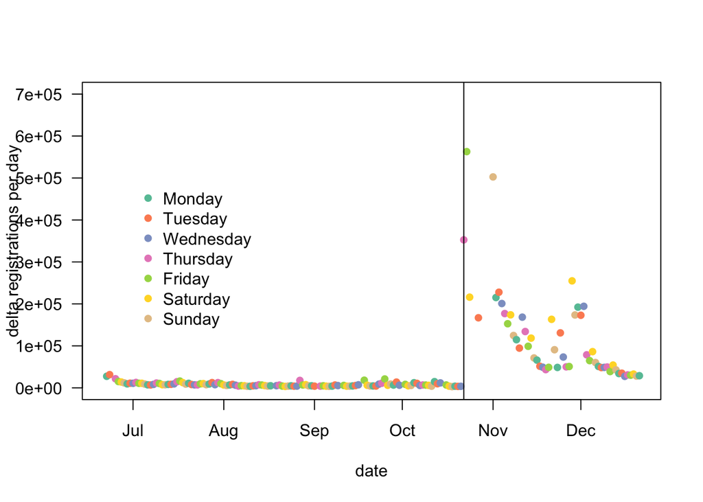

```r
plot(as.Date(dat.all$date), dat.all$diffRegisterPerDay, log = "",
     xlab = "date",
     ylab = "delta registrations per day",
     pch = 16, col = cols[dat.all$weekDay],
     ylim = c(1, 7*10^5))
legend(as.Date("2020-07-01"), y = 500000, legend = names(cols), col = cols, pch = 16, box.lwd = 0)
abline(v = as.Date("2020-10-22"))
```

The vertical line corresponds to the switch from StopCovid to TousAntiCovid. There was an advertisement campaign by the end of November/beginning of December, with SMS sent to the population.

## TAC, QRcodes

### QR codes scanned every day

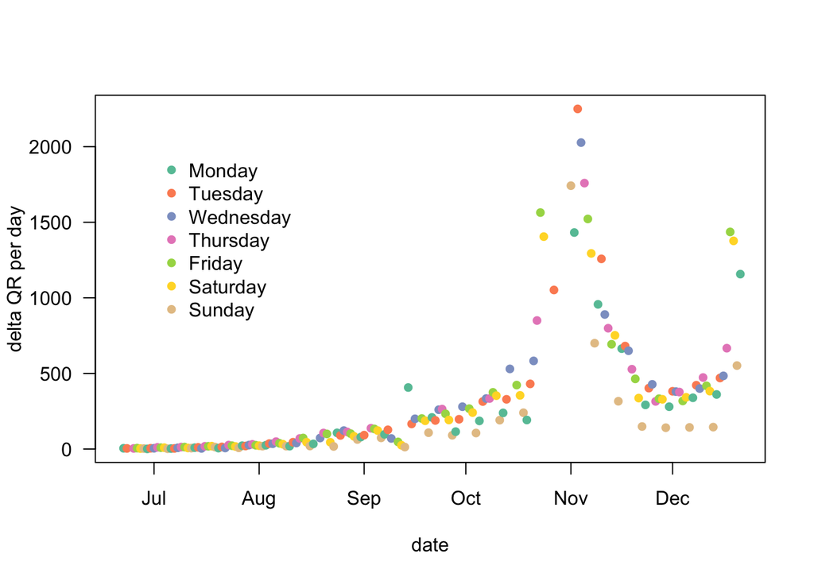

```r
plot(as.Date(dat.all$date), dat.all$diffQRPerDay, log = "",
     xlab = "date",
     ylab = "delta QR per day",
     pch = 16, col = cols[dat.all$weekDay])
legend(as.Date("2020-07-01"), y = 2000, legend = names(cols), col = cols, pch = 16, box.lwd = 0)
```

The minima are on Sundays

## TAC, notifications

### Notifications sent every day

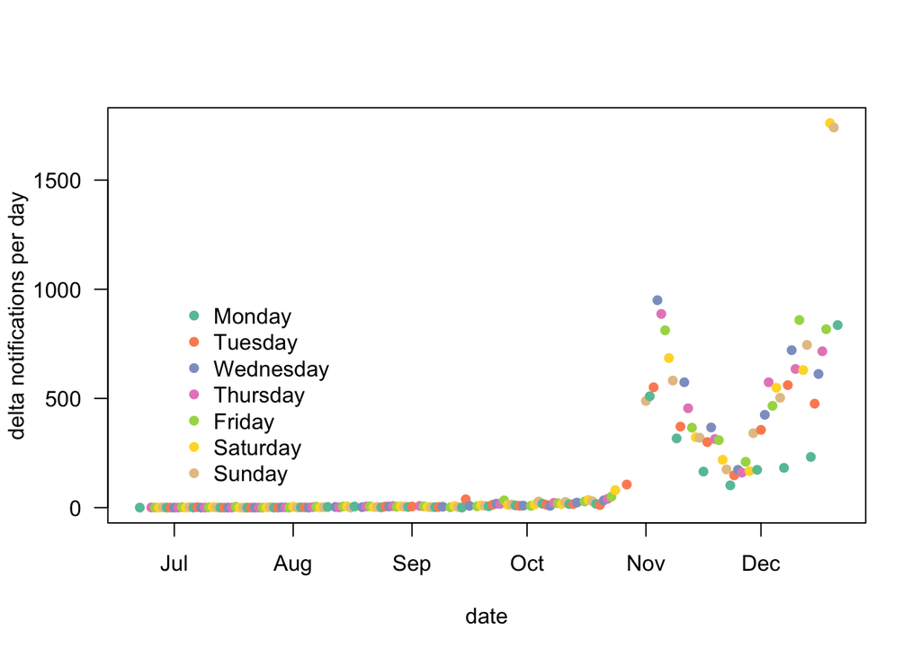

```r
plot(as.Date(dat.all$date), dat.all$diffNotifPerDay, log = "",
     xlab = "date",
     ylab = "delta notifications per day",
     pch = 16, col = cols[dat.all$weekDay])
legend(as.Date("2020-07-01"), y = 1000, legend = names(cols), col = cols, pch = 16, box.lwd = 0)
```

The minima are on Mondays  
-> There seems to be a one-day difference between scanned QR codes and notifications sent. This was already noticed by F. Lesueur [here](https://flesueur.medium.com/réalignement-temporel-des-chiffres-tousanticovid-covid-7bda2f0bf1c1).

### Notifications per QR code

1. same day

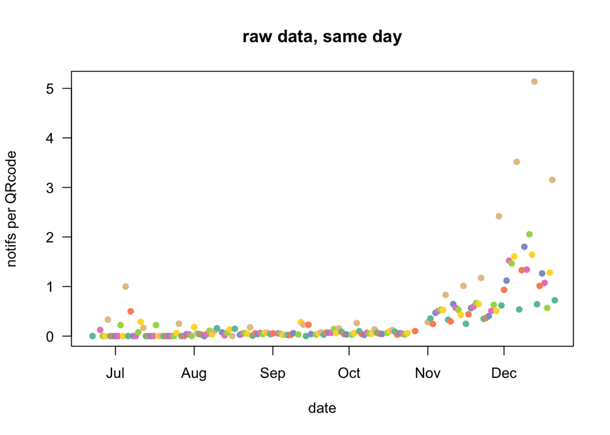

```r
plot(as.Date(dat.all$date), dat.all$diffNotifPerDay / dat.all$diffQRPerDay, log = "",
     xlab = "date",
     ylab = "notifs per QRcode",
     pch = 16, col = cols[dat.all$weekDay], main = "raw data, same day")
```

2. one-day difference

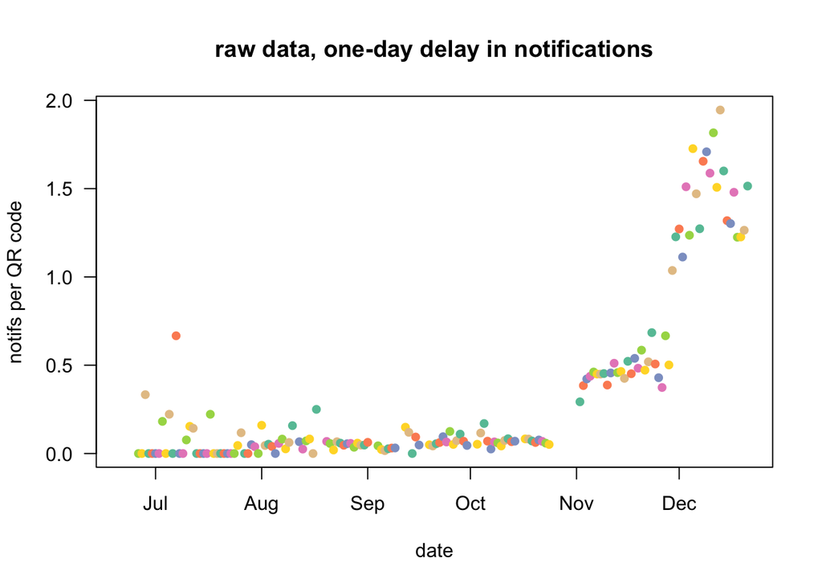

```r
plot(as.Date(dat.all$date), dat.all$diffNotifPerDay / (c(NA, dat.all$diffQRPerDay[-nrow(dat.all)])), log = "",
     xlab = "date",
     ylab = "notifs per QR code",
     pch = 16, col = cols[dat.all$weekDay], main = "raw data, one-day delay in notifications")
```

1. same day, 7-day average

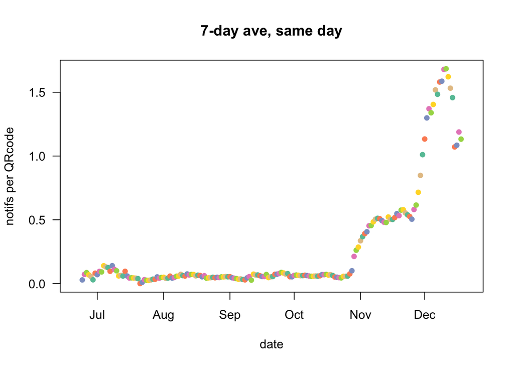

```r
plot(as.Date(dat.all$date), dat.all$diffNotifPerDay.WeekAve / dat.all$diffQRPerDay.WeekAve, log = "",
     xlab = "date",
     ylab = "notifs per QRcode",
     pch = 16, col = cols[dat.all$weekDay], main = "7-day ave, same day")
```

2. one-day difference, 7-day average

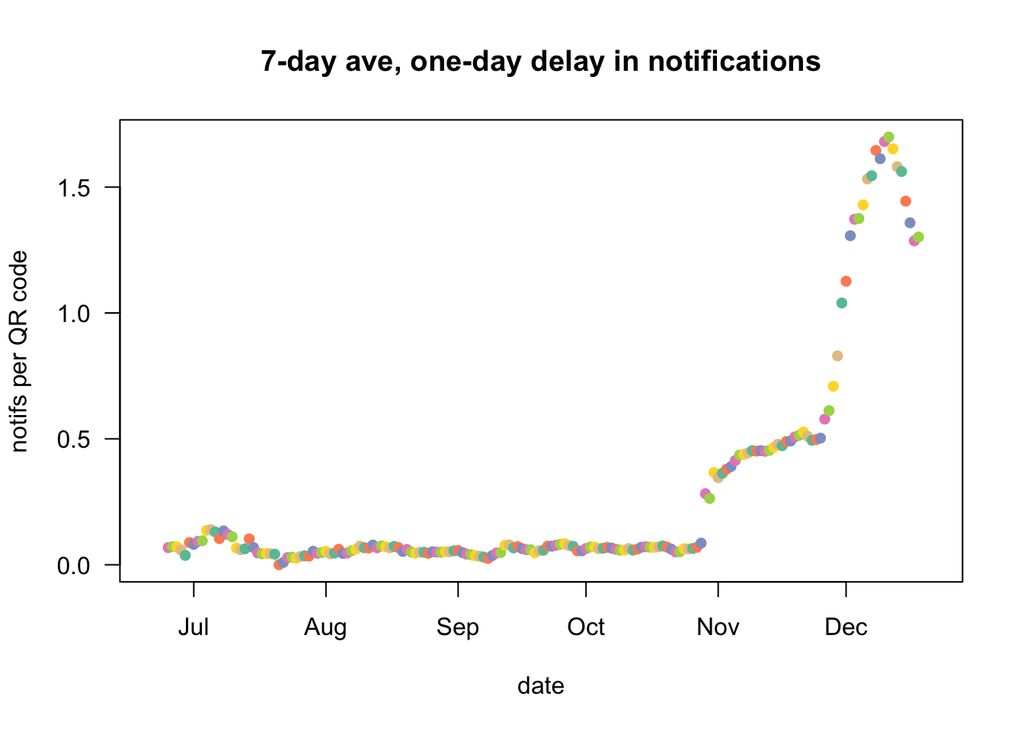

```r
plot(as.Date(dat.all$date), dat.all$diffNotifPerDay.WeekAve / (c(NA, dat.all$diffQRPerDay.WeekAve[-nrow(dat.all)])), log = "",
     xlab = "date",
     ylab = "notifs per QR code",
     pch = 16, col = cols[dat.all$weekDay], main = "7-day ave, one-day delay in notifications")
```

## Active users

Not all users are active; some people have downloaded the app but do not turn on bluetooth; some may just have downloaded the app for their “attestations”.  
To estimate the number of active users, we will compare the proportion of registered users in the whole population to the proportion of scanned QR codes among positive test results.

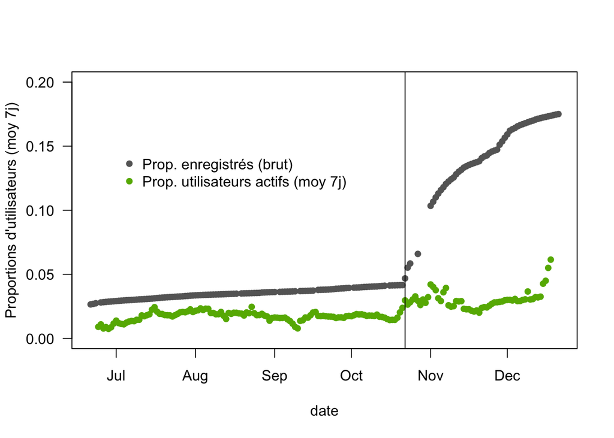

```r
# Approximate size of the French population
popFR <- 67*10^6

propUtil.Raw <- dat.withEpi$register / popFR
propUtil <- dat.withEpi$register.WeekAve / popFR

propUtilActif <- dat.withEpi$diffQRPerDay.WeekAve / dat.withEpi$P.WeekAve

colActif <- rgb(0.4, 0.7, 0)
colRegis <- gray(0.4)
plot(dat.withEpi$date, propUtilActif,
     xlab = "date", ylab = "Proportions d'utilisateurs (moy 7j)", ylim = c(0, 0.2),
     pch = 16, col = colActif)
points(dat.withEpi$date, propUtil.Raw, pch = 16, col = colRegis)
legend(as.Date("2020-07-01"), 0.15, col = c(gray(0.4), rgb(0.4, 0.7, 0)), pch = 16,
       legend = c("Prop. enregistrés (brut)", "Prop. utilisateurs actifs (moy 7j)"),
       box.lwd = 0)
abline(v = as.Date("2020-10-22"))
```

## App settings

We want to see if the conditions to detect a contact have changed over time. If the app remains the same, the proportion of notified cases per QRcode should be a constant multiple of the proportion of app users. Notifications are sent to contacts of the 14? last days (maybe with decreasing proportion when the contact is older).

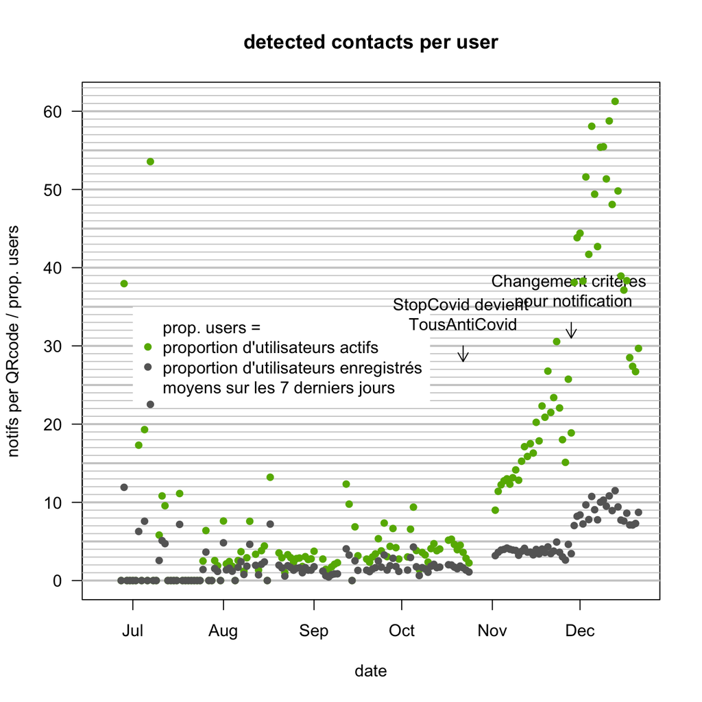

```r
notifsPerQR.raw.decalage <- dat.all$diffNotifPerDay / (c(NA, dat.all$diffQRPerDay[-nrow(dat.all)]))

# Choice of the function over which cases are averaged
aveprop <- function(x){
  sliding.ave(x, winwdt = 7, pos = 7)
}

plot(as.Date(dat.all$date), notifsPerQR.raw.decalage / aveprop(propUtilActif),
     xlab = "date",
     ylab = "notifs per QRcode / prop. users",
     pch = 16, col = colActif, main = "detected contacts per user", type = "n")

for(i in 0:65){
  abline(h = i, col = gray(0.8))
}
for(i in seq(0, 65, by = 5)){
  abline(h = i, col = gray(0.8), lwd = 2)
}

legend(as.Date("2020-07-01"), 35, col = c("white", colActif, colRegis, "white"), pch = 16,
       legend = c("prop. users = ", "proportion d'utilisateurs actifs", "proportion d'utilisateurs enregistrés", "moyens sur les 7 derniers jours"),
       box.lwd = 0)

dy <- 2
yo <- 30
arrows(x0 = as.Date("2020-10-22"), yo, y1 = yo-dy, length = 0.1)
text(x = as.Date("2020-10-22"), y = yo, "StopCovid devient \nTousAntiCovid", adj = c(0.5, -0.5))

yo <- yo + 3
arrows(x0 = as.Date("2020-11-28"), yo, y1 = yo-dy, length = 0.1)
text(x = as.Date("2020-11-28"), y = yo, "Changement critères \n pour notification", adj = c(0.5, -0.5))

points(as.Date(dat.all$date), notifsPerQR.raw.decalage/aveprop(propUtilActif), pch = 16, col = colActif)

points(as.Date(dat.all$date), notifsPerQR.raw.decalage/aveprop(propUtil.Raw), col = colRegis, pch = 16)
```